# Image Processing 2 - Exercise on Morphological Operations

أحمد محمد عبدالله محمد 1300180

# Script

```python
import cv2
import matplotlib
%matplotlib inline
import matplotlib.pyplot as plt
import skimage
from skimage import io
from skimage import filters
import numpy as np
```

# A. Dilation

Dilation is one of the basic operators in the area of morphology. The basic effect of the operator on a binary image is to gradually expand the region boundary of the foreground Pixels.

# 1

In this problem, read the ‘square-circle.png’. Use the dilation operation on this image with two different structuring elements (square and circle). This size of structuring element is of your choice.

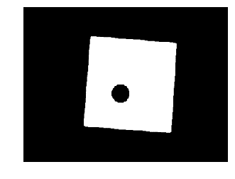

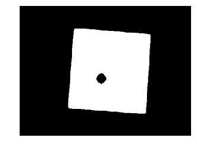

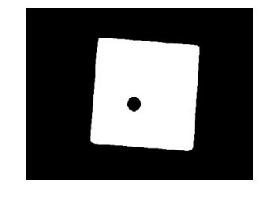

```python
image1 = cv2.imread('Square-circle.png', 1)
plt.axis("off")
plt.imshow(image1)
plt.show()
kernel1_1 = cv2.getStructuringElement(cv2.MORPH_RECT,(10,10))
kernel1_2 = cv2.getStructuringElement(cv2.MORPH_ELLIPSE,(10,10))
d1_1 = cv2.dilate(image1, kernel1_1, iterations=1)
plt.axis("off")
plt.imshow(d1_1)
plt.show()
d1_2 = cv2.dilate(image1, kernel1_2, iterations=1)
plt.axis("off")
plt.imshow(d1_2)
plt.show()
```

# 2

There are many other uses of dilation. For example, it can be used to fill in small spurious holes (‘pepper noise’) in images. In this problem, read the ‘cameraman.png’ image. This image contains pepper noise. Use a suitable structuring element to dilate this image, hence removing the noise from the image. The image quality may not be that great.

[figure not shown]

[figure not shown]

```python
image2 = cv2.imread('Cameraman.png', 1)
plt.axis("off")
plt.imshow(image2)
plt.show()
kernel2 = cv2.getStructuringElement(cv2.MORPH_RECT,(5,5))
d2 = cv2.dilate(image2, kernel2, iterations=1)
plt.axis("off")
plt.imshow(d2)
plt.show()
```

# 3

Edge detection can be accomplished using dilation in conjunction with other operations. There are different methods. Describe how you perform edge detection using dilation. Use the lady.png for this operation.

[figure not shown]

[figure not shown]

```python
image3 = cv2.imread('lady.png', 1)
plt.axis("off")
plt.imshow(image3)
plt.show()
kernel3 = cv2.getStructuringElement(cv2.MORPH_RECT,(5,5))
d3 = cv2.dilate(image3, kernel3, iterations=1)
o3 = d3 - image3
plt.axis("off")
plt.imshow(o3)
plt.show()
```

# B. Erosion

The basic effect of the erosion operator on a binary image is to erode away the boundaries of regions of foreground pixels. Thus the areas of the foreground pixel shrink in size and holes within those areas become larger.

# 4

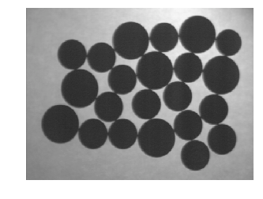

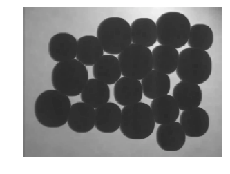

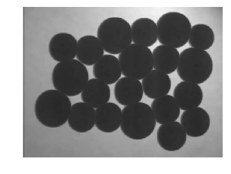

```python
image4 = cv2.imread('Circle.png', 1)
plt.axis("off")
plt.imshow(image4)
plt.show()
kernel4_1 = cv2.getStructuringElement(cv2.MORPH_RECT,(10,10))
kernel4_2 = cv2.getStructuringElement(cv2.MORPH_ELLIPSE,(10,10))
e4_1 = cv2.erode(image4, kernel4_1, iterations=1)
plt.axis("off")
plt.imshow(e4_1)
plt.show()
e4_2 = cv2.erode(image4, kernel4_2, iterations=1)
plt.axis("off")
plt.imshow(e4_2)
plt.show()
```

# 5

The image shows a number of dark disks against a light background. Do a thresholding of this image and then use the erosion operation to display the circles distinctly in the image.

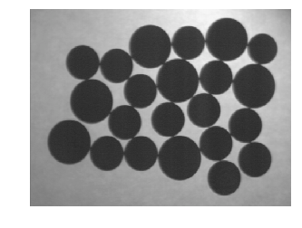

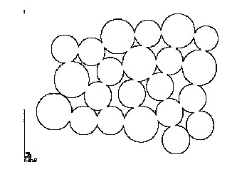

```python
image5 = cv2.imread('Circle.png', 1)
plt.axis("off")
plt.imshow(image5)
plt.show()
ret, thresh5 = cv2.threshold(image5, 127, 255, cv2.THRESH_BINARY)
kernel5 = cv2.getStructuringElement(cv2.MORPH_RECT,(5,5))
e5 = cv2.erode(thresh5, kernel5, iterations=1)
o5 = thresh5 - e5
ret, od5 = cv2.threshold(o5, 127, 255, cv2.THRESH_BINARY_INV)
plt.axis("off")
plt.imshow(od5)
plt.show()
```

# 6 Noise reduction

Using the same image in the problem 2 (cameraman.png) reduce the salt noise in the image using the erosion technique.

[figure not shown]

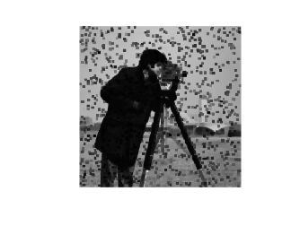

```python
image6 = cv2.imread('Cameraman.png', 1)
plt.axis("off")
plt.imshow(image6)
plt.show()
kernel6 = cv2.getStructuringElement(cv2.MORPH_RECT,(5,5))
e6 = cv2.erode(image6, kernel6, iterations=1)
plt.axis("off")
plt.imshow(e6)
plt.show()
```

# Opening and Closing:

These are operations that are derived from the fundamental operations of erosion and dilation. The basic effect of an opening is like erosion in that it tends to remove some of the foreground (bright) pixels from the edges of regions of foreground pixels. The exact operation is determined by the structural element only. Closing is similar in some ways to dilation, in that it tends to enlarge the boundaries of the foreground regions in an image

# 7

In this section you will be separating out various objects from the images using the opening function. For the given image Circle_and_Lines.png, use the opening technique with the appropriate structuring element.

Your mission is to separate the circles from the lines.

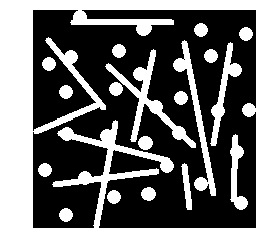

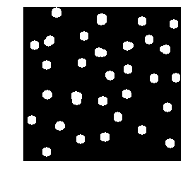

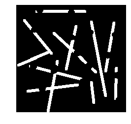

```python
image7 = cv2.imread('Circle_and_Lines.png', 1)
plt.axis("off")
plt.imshow(image7)
plt.show()
kernel7_1 = cv2.getStructuringElement(cv2.MORPH_ELLIPSE,(11,11))
o7 = cv2.morphologyEx(image7, cv2.MORPH_OPEN, kernel7_1)
plt.axis("off")
plt.imshow(o7)
plt.show()
l7 = image7 - o7
kernel7_2 = cv2.getStructuringElement(cv2.MORPH_RECT,(2,2))
o7_2 = cv2.morphologyEx(l7, cv2.MORPH_OPEN, kernel7_2)
plt.axis("off")
plt.imshow(o7_2)
plt.show()
```